# Portfoliomanagement and Financial Analysis - Assignment 3

Submit until Monday 2020-10-07, 13:00

Lukas Salcher

```r
pacman::p_load(tidyverse,tidyquant,FFdownload,PortfolioAnalytics,tsibble,matrixcalc,Matrix,timetk)
```

**Please** remember to put your assignment solutions in `rmd` format using **many** chunks and putting readable text in between, similar to my examples given in Research Methods and Assignment 1! Also, each student has to select his own set of 10 stocks having data available as of `2000-01-01`. Select by Sharpe-ratio, dominance or any other method (e.g. matching your first name).

## Exercise 1: Optimzing portfolios

Take your personal dataset of 10 stocks, set the time-frame to January 2000/ August 2018 (use a year-month format - either `as.yearmon` from `zoo` or `yearmonth` from `tsibble`) and calculate monthly simple returns (if you have not done so yet)! Use `pivot_wider()` and `tk_xts()` to make a `xts` (timeseries) from it (having ten columns with simple returns calculated from adjusted prices).

```r
stock.selection <- sp500 %>%
  inner_join(rbind(nyse,nasdaq) %>% select(symbol, last.sale.price, market.cap, ipo.year),by=c("symbol")) %>%
  dplyr::filter(ipo.year<2000&!is.na(market.cap)) %>%
  arrange(desc(weight)) %>%
  slice(1:10);stock.selection
```

| symbol | company | identifier | sedol | weight | sector | shares_held | local_currency | last.sale.price | market.cap | ipo.year |
| --- | --- | --- | --- | --- | --- | --- | --- | --- | --- | --- |
| AAPL | Apple Inc. | 03783310 | 2046251 | 0.067025694 | Information Technology | 167042620 | USD | 113.02 | $1959.47B | 1980 |
| MSFT | Microsoft Corporation | 59491810 | 2588173 | 0.057396276 | Information Technology | 78631790 | USD | 206.19 | $1560.37B | 1986 |
| AMZN | Amazon.com Inc. | 02313510 | 2000019 | 0.048959247 | Consumer Discretionary | 4423852 | USD | 3125.00 | $1565.28B | 1997 |
| NVDA | NVIDIA Corporation | 67066G10 | 2379504 | 0.011994000 | Information Technology | 6410532 | USD | 522.49 | $322.75B | 1999 |
| ADBE | Adobe Inc. | 00724F10 | 2008154 | 0.008553637 | Information Technology | 4984230 | USD | 478.99 | $229.78B | 1986 |
| CSCO | Cisco Systems Inc. | 17275R10 | 2198163 | 0.005863685 | Information Technology | 43987640 | USD | 38.27 | $162.01B | 1990 |
| AMGN | Amgen Inc. | 03116210 | 2023607 | 0.005339817 | Health Care | 6085750 | USD | 245.41 | $143.74B | 1983 |
| QCOM | QUALCOMM Incorporated | 74752510 | 2714923 | 0.004813998 | Information Technology | 11723493 | USD | 115.47 | $130.28B | 1991 |
| UPS | United Parcel Service Inc. Class B | 91131210 | 2517382 | 0.004226431 | Industrials | 7337728 | USD | 166.96 | $144.15B | 1999 |
| ORCL | Oracle Corporation | 68389X10 | 2661568 | 0.004118815 | Information Technology | 20087904 | USD | 58.83 | $177.13B | 1986 |

```r
stock.prices <- stock.selection$symbol %>%
  tq_get(get="stock.prices", from = "2000-01-01", to = "2018-08-31") %>%
  dplyr::group_by(symbol)

stock.returns <- stock.prices %>%
                  tq_transmute(select = adjusted,
                               mutate_fun = periodReturn,
                               period="monthly",
                               type="arithmetic") %>%
                  ungroup()# %>% mutate(date=as.yearmon(date))
```

```r
xts.returns.wide <- stock.returns %>% pivot_wider(.,names_from=symbol, values_from=monthly.returns) %>% tk_xts(silent = TRUE); round(xts.returns.wide[1:20,],digits = 5)
```

```
               AAPL     MSFT     AMZN     NVDA     ADBE     CSCO     AMGN     QCOM      UPS     ORCL
2000-01-31 -0.07314 -0.16032 -0.27762 -0.20828 -0.16015  0.01330  0.01192 -0.29174 -0.10531 -0.15423
2000-02-29  0.10482 -0.08685  0.06680  0.72681  0.85244  0.20719  0.07066  0.12156 -0.08676  0.48639
2000-03-31  0.18484  0.18881 -0.02722  0.32007  0.09157  0.16974 -0.09991  0.04827  0.15303  0.05135
2000-04-28 -0.08652 -0.34353 -0.17631  0.05493  0.08647 -0.10327 -0.08758 -0.27375  0.05582  0.02402
2000-05-31 -0.32292 -0.10305 -0.12458  0.28050 -0.06925 -0.17872  0.13616 -0.38790 -0.09705 -0.10086
2000-06-30  0.24703  0.27872 -0.24838  0.11391  0.15515  0.11636  0.10413 -0.09605 -0.01618  0.16957
2000-07-31 -0.02983 -0.12734 -0.17040 -0.05605 -0.11923  0.02950 -0.07562  0.08229 -0.00265 -0.10558
2000-08-31  0.19926  0.00000  0.37759  0.32292  0.13537  0.04871  0.16747 -0.07796 -0.05350  0.20948
2000-09-29 -0.57744 -0.13608 -0.07380  0.03150  0.19443 -0.19490 -0.07894  0.18998  0.01691 -0.13402
2000-10-31 -0.24029  0.14197 -0.04715 -0.24103 -0.02013 -0.02489 -0.17028 -0.08618  0.07761 -0.16191
2000-11-30 -0.15655 -0.16697 -0.32594 -0.34825 -0.16680 -0.11137  0.09817  0.23254  0.00179 -0.19697
2000-12-29 -0.09849 -0.24401 -0.36962 -0.19097 -0.08185 -0.20104  0.00491  0.02414 -0.03193  0.09670
2001-01-31  0.45378  0.40778  0.11245  0.57558 -0.24903 -0.02124  0.09971  0.02281  0.05362  0.00215
2001-02-28 -0.15607 -0.03378 -0.41155 -0.13438 -0.33476 -0.36728  0.02489 -0.34796 -0.08380 -0.34764
2001-03-30  0.20931 -0.07309  0.00417  0.45280  0.20375 -0.33245 -0.16479  0.03307  0.00655 -0.23000
2001-04-30  0.15496  0.23886  0.54252  0.28308  0.28453  0.07383  0.01583  0.01298  0.00967  0.10458
2001-05-31 -0.21734  0.02111  0.05767  0.02773 -0.11465  0.13428  0.08570  0.05893  0.03814 -0.05322
2001-06-29  0.16541  0.05522 -0.15219  0.08340  0.18213 -0.05504 -0.08587 -0.03721 -0.02775  0.24183
2001-07-31 -0.19183 -0.09329 -0.11731 -0.12776 -0.20234  0.05604  0.03345  0.08122 -0.01678 -0.04842
2001-08-31 -0.01277 -0.13809 -0.28423  0.04709 -0.10349 -0.15036  0.02535 -0.06927 -0.02482 -0.32467
```

1. As off now, we always perform the following steps before doing anything portfolio related: Check the summary/basic statistics and moments of the assets. Plot and check for (multivariate) normality (OPTIONAL). Check the correlations and do a scatterplot. Check the covariance/correlation structure.

### Basic Statistics:

```r
basicStats(xts.returns.wide)
```

|  | AAPL | MSFT | AMZN | NVDA | ADBE | CSCO | AMGN | QCOM | UPS | ORCL |
| --- | --- | --- | --- | --- | --- | --- | --- | --- | --- | --- |
| nobs | 224.000000 | 224.000000 | 224.000000 | 224.000000 | 224.000000 | 224.000000 | 224.000000 | 224.000000 | 224.000000 | 224.000000 |
| NAs | 0.000000 | 0.000000 | 0.000000 | 0.000000 | 0.000000 | 0.000000 | 0.000000 | 0.000000 | 0.000000 | 0.000000 |
| Minimum | -0.577436 | -0.343530 | -0.411552 | -0.486551 | -0.334764 | -0.367279 | -0.170284 | -0.387896 | -0.229696 | -0.347640 |
| Maximum | 0.453783 | 0.407781 | 0.621777 | 0.826238 | 0.852441 | 0.389163 | 0.328032 | 0.311500 | 0.195240 | 0.486393 |
| 1. Quartile | -0.035910 | -0.038667 | -0.047261 | -0.057097 | -0.043164 | -0.042266 | -0.036235 | -0.048219 | -0.019873 | -0.047181 |
| 3. Quartile | 0.098422 | 0.053869 | 0.096639 | 0.119015 | 0.076943 | 0.059861 | 0.049349 | 0.065698 | 0.039297 | 0.057124 |
| Mean | 0.026191 | 0.008428 | 0.023486 | 0.034938 | 0.018991 | 0.005401 | 0.008552 | 0.005273 | 0.006251 | 0.007369 |
| Median | 0.028449 | 0.016330 | 0.021597 | 0.027327 | 0.029510 | 0.010523 | 0.008557 | 0.010536 | 0.006921 | 0.012935 |
| Sum | 5.866794 | 1.887915 | 5.260961 | 7.826062 | 4.254062 | 1.209750 | 1.915733 | 1.181194 | 1.400284 | 1.650753 |
| SE Mean | 0.007889 | 0.005708 | 0.009285 | 0.012099 | 0.007810 | 0.006624 | 0.004928 | 0.006678 | 0.003681 | 0.006440 |

[output cut: 6 more lines]

### QQ-Plots to check for normality

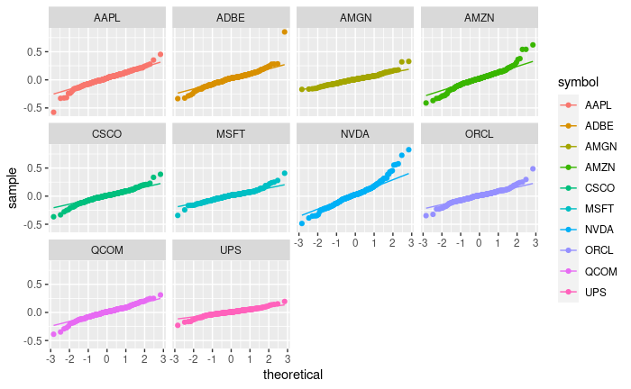

```r
ggplot(stock.returns,
  aes(sample=monthly.returns, color=symbol))+
  stat_qq()+
  stat_qq_line(
  mapping = NULL,
  data = NULL,
  geom = "path",
  position = "identity",
  distribution = stats::qnorm,
  dparams = list(),
  line.p = c(0.25, 0.75),
  fullrange = FALSE,
  na.rm = FALSE,
  show.legend = NA,
  inherit.aes = TRUE)+
  facet_wrap(~symbol)
```

### Scatterplot & Correlations

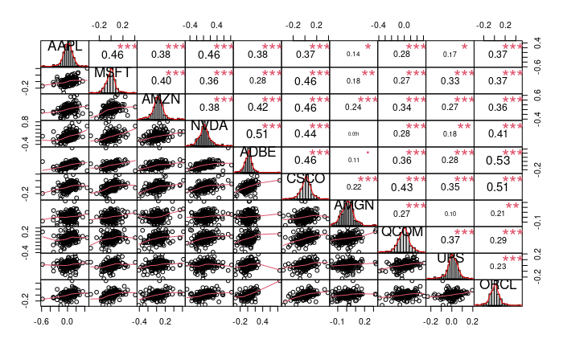

```r
chart.Correlation(xts.returns.wide, histogram=TRUE, pch=19)
```

2. Plot the average return of the assets against their standard deviation. Are there any dominated assets? Plot the efficient frontier using `chart.EfficientFrontier` and `chart.EF.Weights` (also check the `demo(demo_efficient_frontier)` from the `portfolioAnalytics`-package. ### Average Returns vs. Standard Deviation

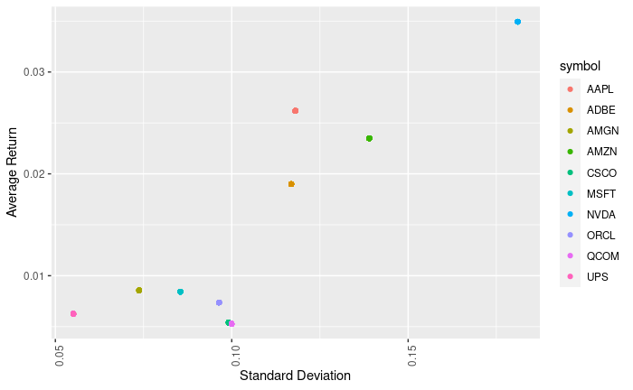

```r
stock.returns %>%
  dplyr::group_by(symbol) %>%
  dplyr::mutate(mean=mean(monthly.returns)) %>%
  dplyr::mutate(sd=sd(monthly.returns)) %>%
  ggplot(.,
  aes(x=sd,y=mean, color=symbol))+
  geom_point()+
  theme(axis.text.x = element_text(angle=90))+
  labs(x="Standard Deviation",
    y="Average Return")
```

### Efficient Frontier & Efficient Weights

```r
stocks <- colnames(xts.returns.wide)
init <- portfolio.spec(assets=stocks)
init <- add.constraint(portfolio=init, type="box", min=0.05, max=0.4)

meanvar.portf <- add.objective(portfolio=init, type="risk", name="var", risk_aversion=10)
meanvar.portf <- add.objective(portfolio=meanvar.portf, type="return", name="mean")
meanvar.ef <- create.EfficientFrontier(R=xts.returns.wide, portfolio=init, type="mean-StdDev")
meanvar.ef
```

```
PortfolioAnalytics Efficient Frontier

Call:
create.EfficientFrontier(R = xts.returns.wide, portfolio = init,
    type = "mean-StdDev")

Efficient Frontier Points: 25

PortfolioAnalytics Portfolio Specification

Call:
portfolio.spec(assets = stocks)

Number of assets: 10
Asset Names
 [1] "AAPL" "MSFT" "AMZN" "NVDA" "ADBE" "CSCO" "AMGN" "QCOM" "UPS"  "ORCL"

Constraints
Enabled constraint types
        - box
```

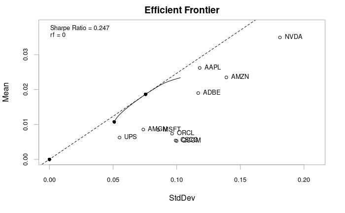

```r
chart.EfficientFrontier(meanvar.ef, match.col="StdDev", type="l", RAR.text="Sharpe Ratio", pch=4)
```

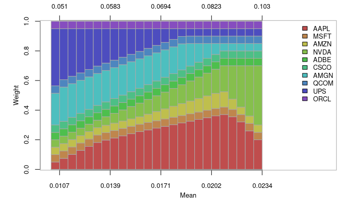

```r
chart.EF.Weights(meanvar.ef, colorset=rainbow12equal, match.col="StdDev")
```

3. Now comes the fun: Work through the vignette of the `portfolioAnalytics`-package (`vignette("portfolio_vignette")`), set a full investment constraint and limit the portfolio weights to be ‘long only’ and calculate minimum-variance/maximum-return and quadratic utility portfolios. Add the investment constraints (i.e no short-selling and no leverage). ### Minimum-Variance

```r
stocks2 <- colnames(xts.returns.wide)
init2 <- portfolio.spec(assets=stocks2)

init2 <- add.constraint(portfolio=init2, type="weight_sum", min_sum=1, max_sum=1)
init2 <- add.constraint(portfolio=init2, type="box", min=0.05, max=0.4)


minvar.portf <- add.objective(portfolio=init2, type="risk", name="var")
minvar.opt <- optimize.portfolio(R=xts.returns.wide, portfolio=minvar.portf, optimize_method="ROI", trace=TRUE)
print(minvar.opt)
```

```
PortfolioAnalytics Optimization

Call:
optimize.portfolio(R = xts.returns.wide, portfolio = minvar.portf,
    optimize_method = "ROI", trace = TRUE)

Optimal Weights:
 AAPL  MSFT  AMZN  NVDA  ADBE  CSCO  AMGN  QCOM   UPS  ORCL
0.050 0.050 0.050 0.050 0.050 0.050 0.214 0.050 0.386 0.050

Objective Measure:
 StdDev
0.05096
```

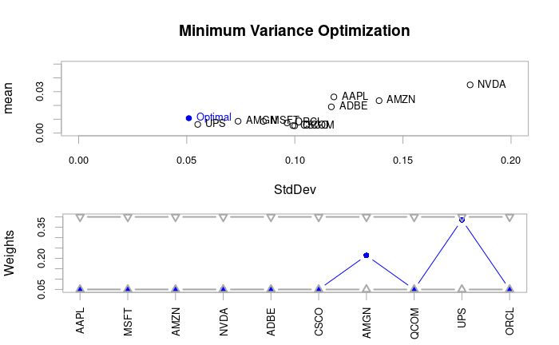

```r
 plot(minvar.opt, risk.col="StdDev", return.col="mean", main="Minimum Variance Optimization", chart.assets=TRUE,xlim=c(0, 0.2), ylim=c(0,0.05))
```

### Maximum-Return

```r
stocks3 <- colnames(xts.returns.wide)
init3 <- portfolio.spec(assets=stocks3)

init3 <- add.constraint(portfolio=init3, type="weight_sum", min_sum=1, max_sum=1)
init3 <- add.constraint(portfolio=init3, type="box", min=0.05, max=0.4)

maxret.portf <- add.objective(portfolio=init3, type="return", name="mean")
maxret.opt <- optimize.portfolio(R=xts.returns.wide, portfolio=maxret.portf, optimize_method="ROI", trace=TRUE)
print(maxret.opt)
```

```
PortfolioAnalytics Optimization

Call:
optimize.portfolio(R = xts.returns.wide, portfolio = maxret.portf,
    optimize_method = "ROI", trace = TRUE)

Optimal Weights:
AAPL MSFT AMZN NVDA ADBE CSCO AMGN QCOM  UPS ORCL
0.20 0.05 0.05 0.40 0.05 0.05 0.05 0.05 0.05 0.05

Objective Measure:
  mean
0.0234
```

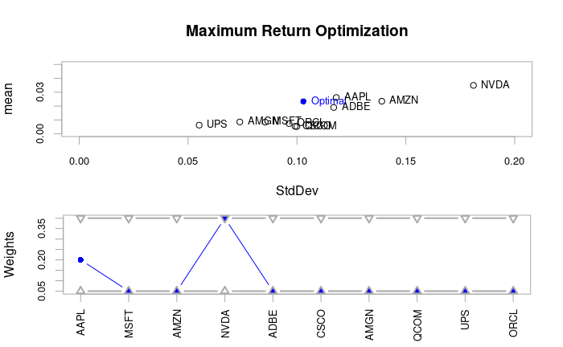

```r
 plot(maxret.opt, risk.col="StdDev", return.col="mean", main="Maximum Return Optimization", chart.assets=TRUE,xlim=c(0, 0.2), ylim=c(0,0.05))
```

### Quadratic Utility

```r
stocks4 <- colnames(xts.returns.wide)
init4 <- portfolio.spec(assets=stocks4)

init4 <- add.constraint(portfolio=init4, type="weight_sum", min_sum=0, max_sum=1)


qu.portf <- add.objective(portfolio=init4, type="return", name="mean")
qu.portf <- add.objective(portfolio=qu.portf, type="risk", name="var", risk_aversion=3)
qu.opt <- optimize.portfolio(R=xts.returns.wide, portfolio=qu.portf, optimize_method="ROI", trace=TRUE)
print(qu.opt)
```

```
PortfolioAnalytics Optimization

Call:
optimize.portfolio(R = xts.returns.wide, portfolio = qu.portf,
    optimize_method = "ROI", trace = TRUE)

Optimal Weights:
   AAPL    MSFT    AMZN    NVDA    ADBE    CSCO    AMGN    QCOM     UPS    ORCL
 0.2487 -0.0808  0.1054  0.1137  0.1137 -0.1980  0.2402 -0.1259  0.3159 -0.1121

Objective Measure:
   mean
0.01591


StdDev
0.0515
```

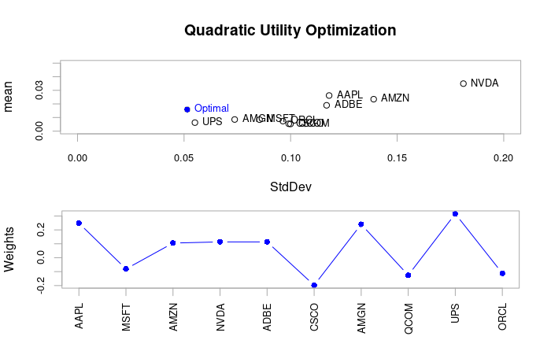

```r
 plot(qu.opt, risk.col="StdDev", return.col="mean", main="Quadratic Utility Optimization", chart.assets=TRUE,xlim=c(0, 0.2), ylim=c(0,0.05))
```

```r
stocks.qu <- colnames(xts.returns.wide)
init.qu <- portfolio.spec(assets=stocks.qu)

init.qu <- add.constraint(portfolio=init.qu, type="box", min=0, max=1)
init.qu <- add.constraint(portfolio=init.qu, type="weight_sum", min_sum=0, max_sum=1)


qu.portf2 <- add.objective(portfolio=init.qu, type="return", name="mean")
qu.portf2 <- add.objective(portfolio=qu.portf2, type="risk", name="var", risk_aversion=3)
qu.opt2 <- optimize.portfolio(R=xts.returns.wide, portfolio=qu.portf2, optimize_method="ROI", trace=TRUE)
print(qu.opt2)
```

```
PortfolioAnalytics Optimization

Call:
optimize.portfolio(R = xts.returns.wide, portfolio = qu.portf2,
    optimize_method = "ROI", trace = TRUE)

Optimal Weights:
  AAPL   MSFT   AMZN   NVDA   ADBE   CSCO   AMGN   QCOM    UPS   ORCL
0.1955 0.0000 0.0514 0.0772 0.0376 0.0000 0.1580 0.0000 0.1503 0.0000

Objective Measure:
   mean
0.01203


 StdDev
0.04478
```

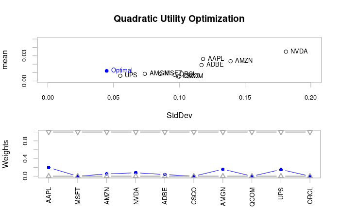

```r
plot(qu.opt2, risk.col="StdDev", return.col="mean", main="Quadratic Utility Optimization", chart.assets=TRUE,xlim=c(0, 0.2), ylim=c(0,0.05))
```

3. Allow for short selling (delete the long only constraint). What happens to your portfolio? Illustrate using the efficient frontier! Combine efficient frontiers using `chart.EfficientFrontierOverlay` to highlight the differences.

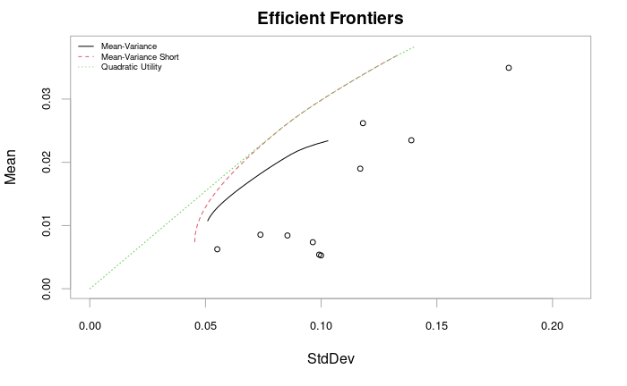

```r
meanvar.portf2 <- add.constraint(portfolio=meanvar.portf, type="box", min=-0.2, max=0.4)
qu.portf <- add.constraint(portfolio=qu.portf, type="box", min=-0.2, max=0.4)

port.list <- combine.portfolios(list(meanvar.portf,meanvar.portf2, qu.portf))

chart.EfficientFrontierOverlay(R=xts.returns.wide,portfolio_list =port.list,type="mean-StdDev", match.col="StdDev", legend.loc="topleft", legend.labels=c("Mean-Variance", "Mean-Variance Short", "Quadratic Utility"), cex.legend=0.6, labels.assets=FALSE, pch.assets=1)
```

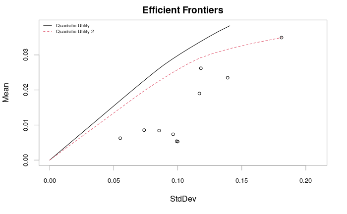

```r
port.list2 <- combine.portfolios(list(qu.portf, qu.portf2))

chart.EfficientFrontierOverlay(R=xts.returns.wide,portfolio_list =port.list2,type="mean-StdDev", match.col="StdDev", legend.loc="topleft", legend.labels=c("Quadratic Utility", "Quadratic Utility 2"), cex.legend=0.6, labels.assets=FALSE, pch.assets=1)
```

4. Play around with the constraints and see what happens. Illustrate using `chart.EfficientFrontierOverlay`.

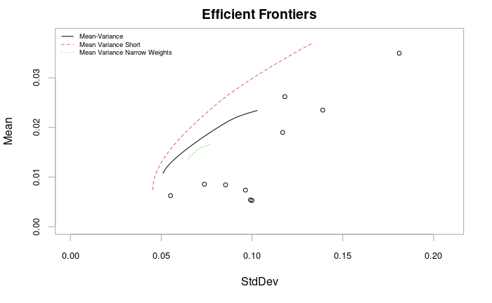

```r
meanvar.portf3 <- add.constraint(portfolio=meanvar.portf, type="box", min=0.09, max=0.2)
port.list3 <- combine.portfolios(list(meanvar.portf, meanvar.portf2, meanvar.portf3))

chart.EfficientFrontierOverlay(R=xts.returns.wide,portfolio_list =port.list3,type="mean-StdDev", match.col="StdDev", legend.loc="topleft", legend.labels=c("Mean-Variance", "Mean Variance Short", "Mean Variance Narrow Weights"), cex.legend=0.6, labels.assets=FALSE, pch.assets=1)
```

## Exercise 2: Do it yourself

In this exercise you first download the IBoxx Euro Corporate All Maturities (“IBCRPAL”) and the EuroStoxx (“DJES50I”) index from Datastream - monthly data as long as possible. We will check the calculations of `R`. Calculate discrete monthly returns.

```r
xts.index.wide <- index.returns %>% pivot_wider(.,names_from=Index, values_from=monthly.returns) %>% tk_xts(silent = TRUE); round(xts.index.wide[1:20,],digits = 5)
```

```
           EURO STOXX 50 - TOT RETURN IND IBOXX EURO CORPORATES - Tot. Rtn Idx Today
2003-05-01                        0.00000                                    0.00000
2003-06-01                        0.03421                                    0.02093
2003-07-01                       -0.00333                                    0.00478
2003-08-01                        0.05035                                   -0.01361
2003-09-01                        0.05040                                    0.00699
2003-10-01                       -0.06216                                    0.01633
2003-11-01                        0.08030                                   -0.00880
2003-12-01                        0.01633                                   -0.00201
2004-01-01                        0.03223                                    0.01416
2004-02-01                        0.03541                                    0.00429
2004-03-01                        0.02265                                    0.01380
2004-04-01                       -0.03253                                    0.00862
2004-05-01                        0.00294                                   -0.00492
2004-06-01                       -0.02407                                   -0.00525
2004-07-01                        0.03941                                    0.00593
2004-08-01                       -0.03767                                    0.00880
2004-09-01                       -0.00018                                    0.01477
2004-10-01                        0.03883                                    0.00456
2004-11-01                        0.01407                                    0.00941
2004-12-01                        0.02924                                    0.01049
```

1. Stats/Normality (see A1)

|  | EURO.STOXX.50...TOT.RETURN.IND | IBOXX.EURO.CORPORATES...Tot..Rtn.Idx.Today |
| --- | --- | --- |
| nobs | 49.000000 | 49.000000 |
| NAs | 0.000000 | 0.000000 |
| Minimum | -0.062159 | -0.013608 |
| Maximum | 0.080301 | 0.020930 |
| 1. Quartile | -0.004781 | -0.003040 |
| 3. Quartile | 0.035737 | 0.009415 |
| Mean | 0.016049 | 0.003381 |
| Median | 0.021040 | 0.004292 |
| Sum | 0.786389 | 0.165676 |
| SE Mean | 0.004562 | 0.001153 |

[output cut: 6 more lines]

[figure not shown]

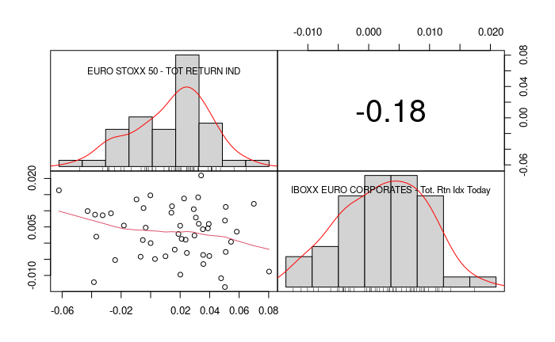

```r
chart.Correlation(xts.index.wide, histogram=TRUE, pch=19)
```

2. Get the necessary input parameters (mu, sigma, please using variables, I don’t want to see manual numbers in your code) and calculate the Minimum-Variance-Portfolio (manually in R). Then do it using the `portfolioAnalytics`-package.

```r
w.iboxx.opt
```

```
                               IBOXX EURO CORPORATES - Tot. Rtn Idx Today
EURO STOXX 50 - TOT RETURN IND                                  0.9045951
```

```r
print(minvar.opt)
```

```
PortfolioAnalytics Optimization

Call:
optimize.portfolio(R = xts.index.wide, portfolio = minvar.indices,
    optimize_method = "ROI", trace = TRUE)

Optimal Weights:
            EURO STOXX 50 - TOT RETURN IND IBOXX EURO CORPORATES - Tot. Rtn Idx Today
                                   -0.0195                                     1.0195

Objective Measure:
  StdDev
0.009154
```

3. Now assume a risk-free rate of 0 and calculate the Tangency-Portfolio manually and with the `portfolioAnalytics`-package. What is the slope of the CAL? Plot a mu-sigma-diagram including all relevant information. What are your portfolio weights and weighted returns? Additionally allow for shortselling and check for changes.

```r
cov.stoxx.iboxx <- cov(xts.index.wide[,1],xts.index.wide[,2])

w.stoxx.tp <- (mu.stoxx*sigma.iboxx^2-mu.iboxx*cov.stoxx.iboxx)/(mu.stoxx*sigma.iboxx^2+mu.iboxx*sigma.stoxx^2-(mu.stoxx+mu.iboxx)*cov.stoxx.iboxx)
w.iboxx.tp <- 1-w.stoxx.tp
```

If we once more assume that the full-investment constraint is the only constraint we have, then we would short -2.88% of the Euro Stoxx 50 Index and go long in 102.88% of the Iboxx Euro Corporate Index.

```r
indices <- colnames(xts.index.wide)

init6 <- portfolio.spec(assets=indices)
init6 <- add.constraint(portfolio=init6, type="full_investment")
init6 <- add.constraint(portfolio=init6, type="box", min=-1, max=2)

meanvar.indices <- add.objective(portfolio=init6, type="risk", name="StdDev")
meanvar.indices <- add.objective(portfolio=meanvar.indices, type="return", name="mean")
meanvar.tp <- optimize.portfolio(R=xts.index.wide, portfolio=meanvar.indices, optimize_method="ROI", trace=TRUE, maxSR=TRUE)
print(meanvar.tp)
```

```
PortfolioAnalytics Optimization

Call:
optimize.portfolio(R = xts.index.wide, portfolio = meanvar.indices,
    optimize_method = "ROI", trace = TRUE, maxSR = TRUE)

Optimal Weights:
            EURO STOXX 50 - TOT RETURN IND IBOXX EURO CORPORATES - Tot. Rtn Idx Today
                                   -0.0288                                     1.0288

Objective Measure:
 StdDev
0.01151

    mean
0.003634
```

```r
sd.tp
```

```
                               IBOXX EURO CORPORATES - Tot. Rtn Idx Today
EURO STOXX 50 - TOT RETURN IND                                0.007662531
```

The weights of the tangency portfolio are as follows:

- EuroStoxx 50 Index : -2.88%
- Iboxx Euro Corporate Index: 102.88%

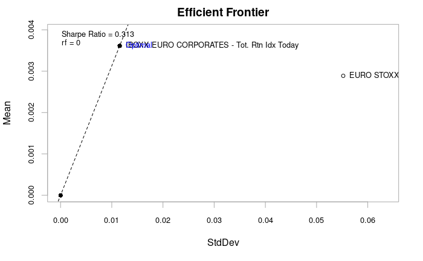

As we already had no short-selling constraint for the previous portfolios nothing really changes. Introducing a short-selling constraint without any other constraint will result in an optimal portfolio that invests a 100% of its capital into the Iboxx Euro Corporate Index as can be seen below.

```r
init6 <- add.constraint(portfolio=init6, type="weight_sum", min_sum=1, max_sum=1)
init6 <- add.constraint(portfolio=init6, type="box", min=0, max=1)

meanvar.indices <- add.objective(portfolio=init6, type="risk", name="var", risk_aversion=13.6)
meanvar.indices <- add.objective(portfolio=meanvar.indices, type="return", name="mean")
meanvar.tp <- optimize.portfolio(R=xts.index.wide, portfolio=meanvar.indices, optimize_method="ROI", trace=TRUE)
print(meanvar.tp)
```

```
PortfolioAnalytics Optimization

Call:
optimize.portfolio(R = xts.index.wide, portfolio = meanvar.indices,
    optimize_method = "ROI", trace = TRUE)

Optimal Weights:
            EURO STOXX 50 - TOT RETURN IND IBOXX EURO CORPORATES - Tot. Rtn Idx Today
                                         0                                          1

Objective Measure:
    mean
0.003613


 StdDev
0.01155
```

4. Now, assume a risk-aversion of A=1, 2 or 3 and calculate your optimal complete portfolio (see lecture slides).

```r
sd.tp
```

[output not shown]

## Exercise 3: Covariance Problems

In the first part of this exercise we will be checking covariances and portfolios that might occur from faulty correlation matrices. We use the covariance matrix from our example

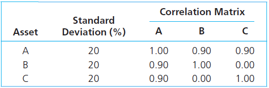

where we additionally assume mean returns of 10% for all three assets. If we define $\mu$ to be the vector of mean returns and $\sigma$ the vector of standard deviations, we can calculate the covariance matrix $\Sigma$ as $\Sigma=diag(\sigma)\cdot R\cdot diag(\sigma)$, where $R$ is the correlation matrix (as in the table above) and $diag$ puts the three standard deviations into the diagonal of a matrix.

```r
mu <- as.vector(c(0.1,0.1,0.1))
sd <- as.vector(c(0.2,0.2,0.2))
cor.mat <- matrix(c(1,0.9,0.9,0.9,1,0,0.9,0,1),nrow=3,ncol=3)
cov.mat <- diag(sd,names=TRUE)%*%cor.mat%*%diag(sd,names=TRUE); cov.mat
```

```
      [,1]  [,2]  [,3]
[1,] 0.040 0.036 0.036
[2,] 0.036 0.040 0.000
[3,] 0.036 0.000 0.040
```

Now we can calculate the Minimum-Variance-Portfolio using matrix calculus as $w_MP=\frac{\Sigma^{-1}\cdot 1'}{1\cdot\Sigma^{-1}\cdot 1'}$ where 1 is a vector of ones with dimension equal to the number of assets. Similarly one can calculate the tangency portfolio as $w_TP=\frac{\Sigma^{-1}\cdot (\mu-r_f)'}{1\cdot\Sigma^{-1}\cdot (\mu-r_f)'}$.

```r
mvp.faulty
```

```
           [,1]
[1,]  1.3333333
[2,] -0.1666667
[3,] -0.1666667
```

```r
tp.faulty.var
```

```
           [,1]
[1,] 0.04133333
```

In this case the MVP has the same mean and variance as the TP.

```r
w.sd
```

```
       [,1]
[1,] -0.024
```

If we use these weights and the faulty correlation matrix we get a negative variance for the portfolio.

So to get used to the necessary tools, we use the package “matrixcalc” wherein we have a function `is.positive.semi.definite()` that can check covariance/correlation matrices for positive semidefiniteness. In the package `Matrix` we find a function `nearPD` that can help us to create a valid correlation matrix. Try and calculate the weights of the MVP and the TP, and then calculate portfolio mean and variance using $\mu_P=w\cdot \mu'$ and $\sigma_P^2=w\cdot \Sigma\cdot w'$ for the MVP and the TP as well as the weight vector w=(-1,1,1). Do this for the faulty matrix as well as the corrected one. What do you observe?

```r
is.positive.semi.definite(cov.mat)
```

```r
new.cor.mat <-nearPD(cor.mat, keepDiag=TRUE)
new.cov.mat <- diag(sd)%*%new.cor.mat$mat%*%diag(sd)
is.positive.semi.definite(inv.new.cov.mat)
```

```r
mvp
```

```
          [,1]
[1,] -2.897274
[2,]  1.948637
[3,]  1.948637
```

```r
mu-rf
```

```
[1] 0.08 0.08 0.08
```